# Head First - Análise de Dados

Marcelo Muzlli

Novembro de 2018

# Capítulo 9

**Mostra a estatística resumida da coluna Recebido no Dataset**

```
##    Min. 1st Qu.  Median    Mean 3rd Qu.    Max.
##  -1.800   4.600   5.500   6.028   6.700  25.900
```

```
## [1] 2.432138
```

**Lista a estrutura do Dataset**

```
## 'data.frame':    3000 obs. of  5 variables:
##  $ X        : int  1 2 3 4 5 6 7 8 9 10 ...
##  $ Recebido : num  12.1 8.9 8.8 7.1 10.2 7 15.1 16 8.2 10.5 ...
##  $ Negociado: Factor w/ 2 levels "FALSO","VERDADEIRO": 2 2 2 2 2 2 2 2 2 2 ...
##  $ Sexo     : Factor w/ 2 levels "F","M": 2 1 2 1 2 1 2 1 2 1 ...
##  $ Ano      : int  2005 2006 2007 2008 2009 2005 2006 2007 2008 2009 ...
```

*Plota o Historgrama*

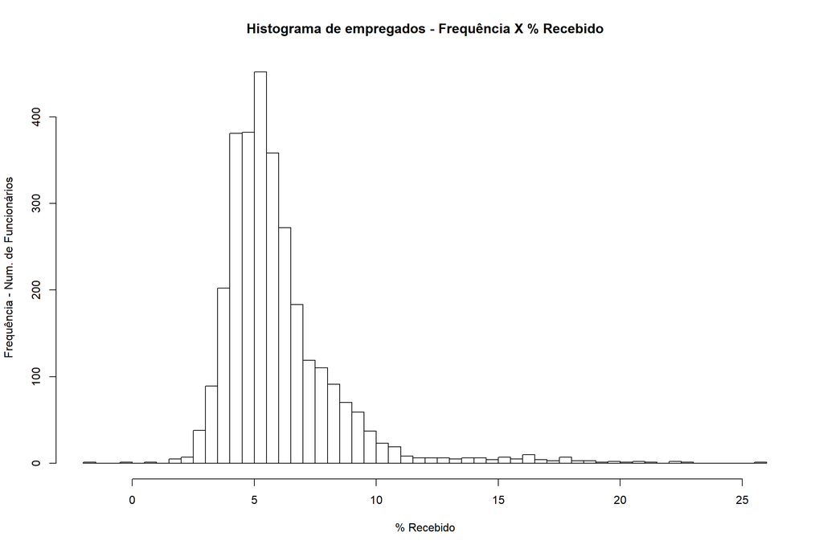

*Plota o Historgrama - Ano 2007*

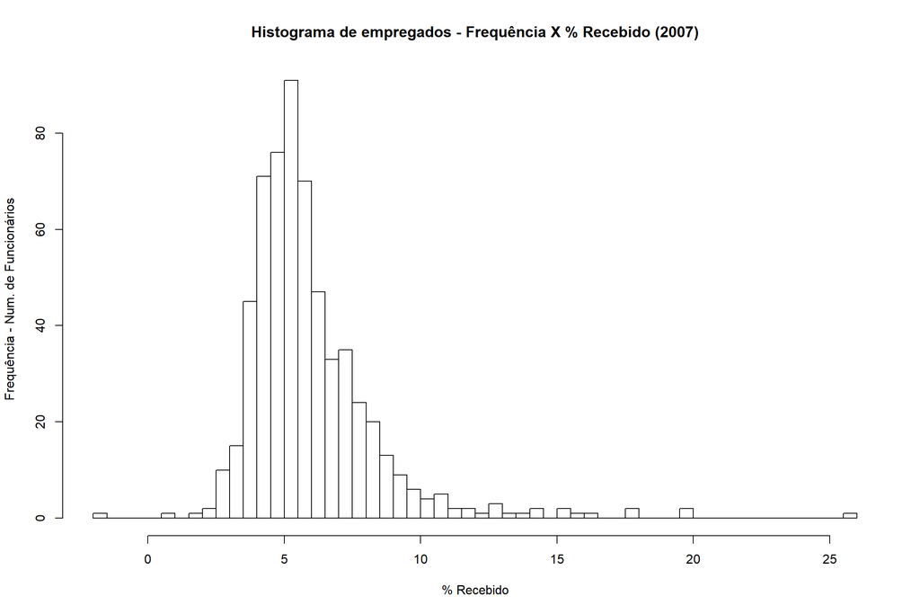

*Divisão do Histograma em Subconjuntos - Classificando somente para o ano de 2008*

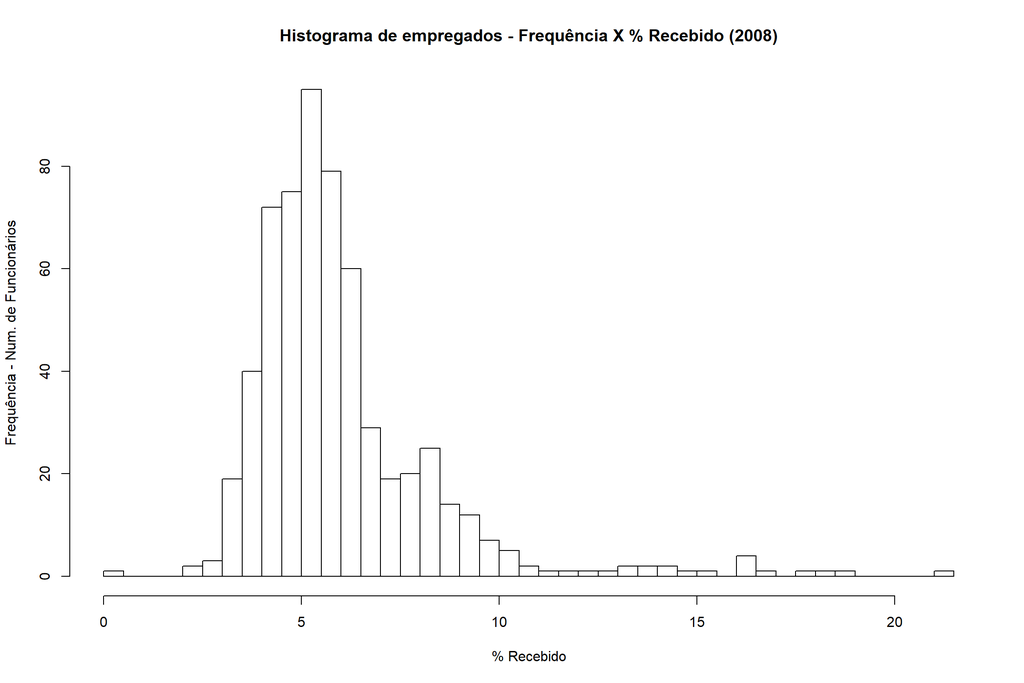

*Divisão do Histograma em Subconjuntos - Classificando somente para as Mulheres*

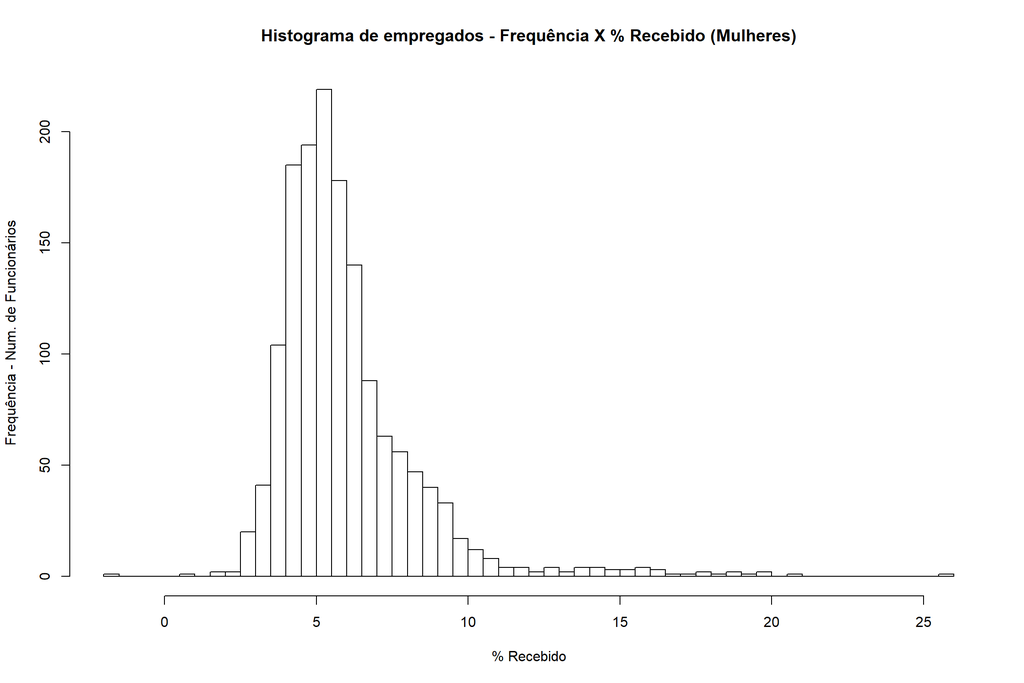

*Divisão do Histograma em Subconjuntos - Classificando somente para os Homens*

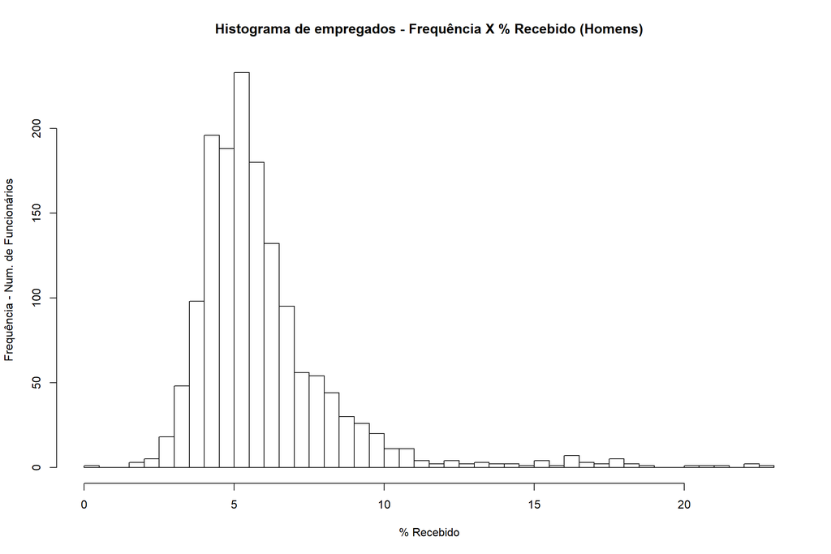

*Divisão do Histograma em Subconjuntos - Classificando somente para os não negocioado*

Nota-se o uso do parâmetro ‘probability’, que estabelece que os valores do histograma serão definidos de forma a que a área total das suas barras some 1. Esta alteração é necessária para normalizar os valores, sendo assim, comparáveis com os gerados pela função ‘densidade_valor_nao_negociado’ acima.

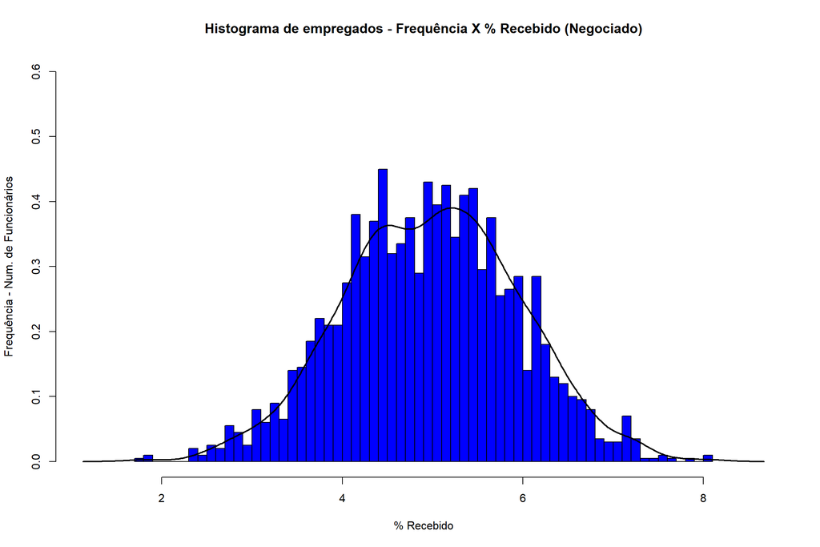

Resultado Finais

```
##    Min. 1st Qu.  Median    Mean 3rd Qu.    Max.
##  -1.800   6.300   7.600   8.096   9.000  25.900
```

```
## [1] 3.077446
```

# Capítulo 10

### Regressão Linear

*função lm()*

**Demonstra os 30 primeiros registros do arquivo CSV**

```
##     X received requested negotiated gender year
## 1   1     12.1       9.5       TRUE      M 2005
## 2   2      8.9       9.9       TRUE      F 2006
## 3   3      8.8      18.1       TRUE      M 2007
## 4   4      7.1      11.8       TRUE      F 2008
## 5   5     10.2      12.5       TRUE      M 2009
## 6   6      7.0      10.2       TRUE      F 2005
## 7   7     15.1       9.3       TRUE      M 2006
## 8   8     16.0      10.7       TRUE      F 2007
## 9   9      8.2      11.4       TRUE      M 2008
## 10 10     10.5      15.0       TRUE      F 2009
## 11 11      1.9       4.4       TRUE      M 2005
## 12 12      9.7      13.4       TRUE      F 2006
## 13 13      9.9      10.1       TRUE      M 2007
## 14 14     13.4       9.0       TRUE      F 2008
```

[output cut: 16 more lines]

**Descrição da funçao de Regressão Linear**

```
y = a + (b * x), onde a = intercepção e b = inclinação
 y = Aumento Recebido
 x = Aumento Solicitado
```

```
Inclinação da Linha = coeficiente de correlação multiplicado pelo desvio padrão de y, dividido pelo desvio padrão de x
 Fórmula = Valor Dependente (Y) ~ Valor Independente (X)
```

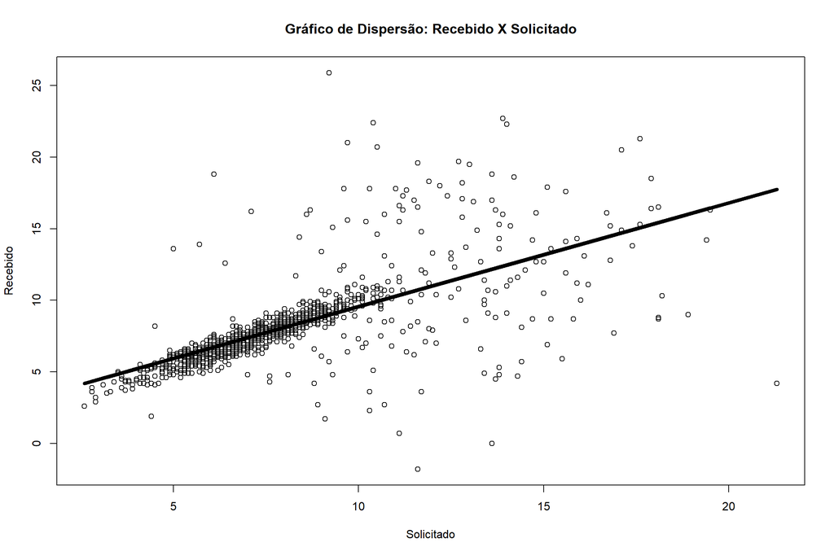

*Imprime o Valor possivel de um aumento esperado onde a porcentam de aumento será de 05%*

```
## (Intercept)
##     5.93746
```

*Margem de Erro (RMS - Desvio Padrão) do Modelo Principal*

```
## [1] "2.3 %"
```

*Margem de Erro (RMS - Desvio Padrão) dos Modelos Small e Big*

```
## [1] "Small:  1.37 %"
```

```
## [1] "Big:  4.54 %"
```

# Capítulo 12

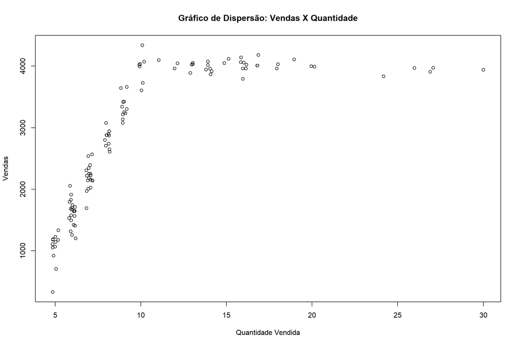

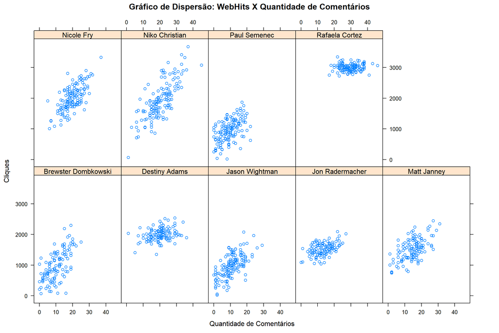

### Análise do **Gráfico de Dispersão** acima

E com relação aos outros autores, alguns deles (como *Destiny* e *Nicole*) parecem se sair melhor que o restante. O *Niko* tem uma grande disseminação no desempenho, enquanto *Brewster* e *Jason* não são populares.

# Capítulo 13

### Data Wrangling

#### Limpeza de Registros Duplicados em um Dataset e remoção de colunas não necessárias

#### Antes

Mostra as 10 Primeiras Linhas do Dataset antes da limpeza (registros duplicados e todas as colunas)

```
##    PersonID FirstName          LastName   ZIP        Phone CallID
## 1       127    Alexia Rasmuss(ID 127)en 11422 718-534-2403   4252
## 2        98   Brenden  Rasmuss(ID 98)en 10015 646-812-7298   4253
## 3        94      Beau       Ware(ID 94) 10013 646-391-9926   4254
## 4       127    Alexia Ra(ID 127)smussen 11422 718-534-2403   4255
## 5       156    Jacoby      Co(ID 156)ok 10045 917-808-6186   4256
## 6       139   Quinten   Hubba(ID 139)rd 10016 917-687-2256   4257
## 7        75 Remington    Farr(ID 75)ell 11693 917-843-4608   4258
## 8        91     Pedro      Pay(ID 91)ne 10005 212-498-6862   4259
## 9       152   Elianna    Me(ID 152)dina 10308 646-819-2778   4260
## 10        8    Darren       Burn(ID 8)s 10120 212-220-3311   4261
##              Time
## 1  1/1/2008 12:32
## 2  1/2/2008 13:17
## 3  1/2/2008 14:54
## 4  1/3/2008 15:32
## 5  1/3/2008 15:52
## 6  1/4/2008 13:19
## 7   1/5/2008 9:09
## 8   1/5/2008 9:10
## 9   1/5/2008 9:41
## 10 1/5/2008 16:11
```

#### Depois

Mostra as 10 Primeiras Linhas do Dataset totalmente limpo (sem registros duplicados e remoção de colunas não necessárias)

```
##     PersonID FirstName   ZIP        Phone    LastName
## 63         1    Jaylen 10006 646-376-4466 Christensen
## 20         2  Reynaldo 11223 646-382-3431      Harris
## 311        3    Yandel 10099 718-510-6575    Franklin
## 183        4       Lia 11230 718-664-9574       Short
## 52         5      Cael 10026 646-623-7673      Glover
## 867        6   Patrick 11222 917-284-5780       Hodge
## 12         7 Jaqueline 10106 347-409-5439       Ewing
## 10         8    Darren 10120 212-220-3311       Burns
## 139        9 Rigoberto 11358 212-537-6720        Mayo
## 28        10     Aliya 11366 917-613-6421     Hoffman
```

*Grava* o Dataset em novo arquivo CSV: ucad_cap13_dados_para_R_nduplicado.csv